# Ames Housing Model Analysis, Part 2

Steven Slezak

31 March 2018

In Part 2 of the *Ames* data modeling exercise, we continue from the regression benchmark laid down [in Part 1.](https://seslezak.github.io/Ames_Housing_Study/Ames_Models_Pt01.html) We further explore feature selection using methods such as cross validation and principle component regression. We will also use other models – ridge regression, the lasso, decision trees, random forests, bagging, boosting, and SVM – to work the data and develop predictions regarding house prices in Ames.

We are working with the same *Ames* data set as in Part 1, but it will be structured a bit differently in this section. Previously, we combined the Kaggle *train.csv* and *test.csv*, performed data preparation, then separated the file into training and test files. In this part, we will work with the *train.csv* file, which we will split into training and test sets in order to train and tune models and parameters.

# 1 Cleaning the Data

The first code chunk goes through the process of preparing and cleaning the *Ames* data. This routine operation has been covered before, so we will suppress the results. Once through this step, we can deploy the data for feature selection and modeling purposes.

```r
library(tidyverse)
library(ggplot2)
library(rapportools)
library(ragtop)
library(corrplot)
library(usdm)
library(fastDummies)
library(broom)
library(car)
library(leaps)
library(glmnet)
library(pls)
library(tree)
library(randomForest)
library(gbm)
library(e1071)

AmesTr <- read.csv('C:/Users/Steven/Desktop/R Projects/UCLA DSI/Test 3/train.csv',
                   stringsAsFactors = FALSE, na.strings = c('', "NA"))
AmesTst <- read.csv('C:/Users/Steven/Desktop/R Projects/UCLA DSI/Test 3/test.csv',
                    stringsAsFactors = FALSE, na.strings = c('', "NA"))

head(AmesTr)
head(AmesTst)
dim(AmesTr)
dim(AmesTst)
str(AmesTr)
str(AmesTst)
str(Filter(is.numeric, AmesTr))
AmesTr$Id <- NULL
sorted <- AmesTr[order(AmesTr$GrLivArea, decreasing = TRUE), ]
head(sorted)
dim(AmesTr)
AmesTr <- AmesTr[-c(1299, 524, 1183, 692), ]
AmesTst <- AmesTst[-c(1299, 524, 1183), ]
dim(AmesTr)
dim(AmesTst)
pryr::object_size(AmesTr)
anyDuplicated(AmesTr)
summary(AmesTr)
str(AmesTr)

AmesTr$MSSubClass <- as.factor(AmesTr$MSSubClass)
AmesTr$OverallQual <- as.factor(AmesTr$OverallQual)
AmesTr$OverallCond <- as.factor(AmesTr$OverallCond)
AmesTr$BsmtFullBath <- as.factor(AmesTr$BsmtFullBath)
AmesTr$BsmtHalfBath <- as.factor(AmesTr$BsmtHalfBath)
AmesTr$FullBath <- as.factor(AmesTr$FullBath)
AmesTr$HalfBath <- as.factor(AmesTr$HalfBath)
AmesTr$BedroomAbvGr <- as.factor(AmesTr$BedroomAbvGr)
AmesTr$KitchenAbvGr <- as.factor(AmesTr$KitchenAbvGr)
AmesTr$TotRmsAbvGrd <- as.factor(AmesTr$TotRmsAbvGrd)
AmesTr$Fireplaces <- as.factor(AmesTr$Fireplaces)
AmesTr$GarageCars <- as.factor(AmesTr$GarageCars)
AmesTr$MoSold <- as.factor(AmesTr$MoSold)

sum(is.na(AmesTr))
sum(is.empty(AmesTr))
nan_sums <- colSums(is.na(AmesTr))
nan_sums[nan_sums > 0]
match(c('Alley', 'PoolArea', 'PoolQC', 'Fence', 'MiscFeature'), names(AmesTr))

AmesTr <- AmesTr[, -c(6, 71:74)]
dim(AmesTr)

medianLotFrontage <- median(AmesTr$LotFrontage, na.rm = TRUE)
medianMasVnrArea <- median(AmesTr$MasVnrArea, na.rm = TRUE)
medianBsmtFinSF1 <- median(AmesTr$BsmtFinSF1, na.rm = TRUE)
medianBsmtFinSF2 <- median(AmesTr$BsmtFinSF2, na.rm = TRUE)
medianBsmtUnfSF <- median(AmesTr$BsmtUnfSF, na.rm = TRUE)
medianTotalBsmtSF <- median(AmesTr$TotalBsmtSF, na.rm = TRUE)
medianGarageYrBlt <- median(AmesTr$GarageYrBlt, na.rm = TRUE)
medianGarageArea <- median(AmesTr$GarageArea, na.rm = TRUE)

AmesTr$LotFrontage[is.na(AmesTr$LotFrontage)] <- medianLotFrontage
AmesTr$MasVnrArea[is.na(AmesTr$MasVnrArea)] <- medianMasVnrArea
AmesTr$BsmtFinSF1[is.na(AmesTr$BsmtFinSF1)] <- medianBsmtFinSF1
AmesTr$BsmtFinSF2[is.na(AmesTr$BsmtFinSF2)] <- medianBsmtFinSF2
AmesTr$BsmtUnfSF[is.na(AmesTr$BsmtUnfSF)] <- medianBsmtUnfSF
AmesTr$TotalBsmtSF[is.na(AmesTr$TotalBsmtSF)] <- medianTotalBsmtSF
AmesTr$GarageYrBlt[is.na(AmesTr$GarageYrBlt)] <- medianGarageYrBlt
AmesTr$GarageArea[is.na(AmesTr$GarageArea)] <- medianGarageArea
nan_sums <- colSums(is.na(AmesTr))
nan_sums[nan_sums > 0]
sum(is.empty(AmesTr))

AmesTr$BsmtFullBath <- as.character(AmesTr$BsmtFullBath)
AmesTr$BsmtHalfBath <- as.character(AmesTr$BsmtHalfBath)
AmesTr$GarageCars <- as.character(AmesTr$GarageCars)

AmesTr$BsmtQual[is.na(AmesTr$BsmtQual)] <- 'w/o'
AmesTr$BsmtCond[is.na(AmesTr$BsmtCond)] <- 'w/o'
AmesTr$BsmtExposure[is.na(AmesTr$BsmtExposure)] <- 'w/o'
AmesTr$BsmtFinType1[is.na(AmesTr$BsmtFinType1)] <- 'w/o'
AmesTr$BsmtFinType2[is.na(AmesTr$BsmtFinType2)] <- 'w/o'
AmesTr$BsmtFullBath[is.na(AmesTr$BsmtFullBath)] <- 'w/o'
AmesTr$BsmtHalfBath[is.na(AmesTr$BsmtHalfBath)] <- 'w/o'
AmesTr$FireplaceQu[is.na(AmesTr$FireplaceQu)] <- 'w/o'
AmesTr$GarageType[is.na(AmesTr$GarageType)] <- 'w/o'
AmesTr$GarageFinish[is.na(AmesTr$GarageFinish)] <- 'w/o'
AmesTr$GarageCars[is.na(AmesTr$GarageCars)] <- 'w/o'
AmesTr$GarageQual[is.na(AmesTr$GarageQual)] <- 'w/o'
AmesTr$GarageCond[is.na(AmesTr$GarageCond)] <- 'w/o'

AmesTr <- as.data.frame(unclass(AmesTr))
str(AmesTr)
sum(is.empty(AmesTr))
nan_sums[nan_sums > 0]

nan_sums <- colSums(is.na(AmesTr))
nan_sums[nan_sums > 0]
sum(is.empty(AmesTr$Electrical))
sum(is.empty(AmesTr$MasVnrType))
sum(is.empty(AmesTr))
str(Filter(is.numeric, AmesTr))
```

There were issues with collinearity in the first part of the study. We would expect them to persist here, so let’s run a sanity check to make sure.

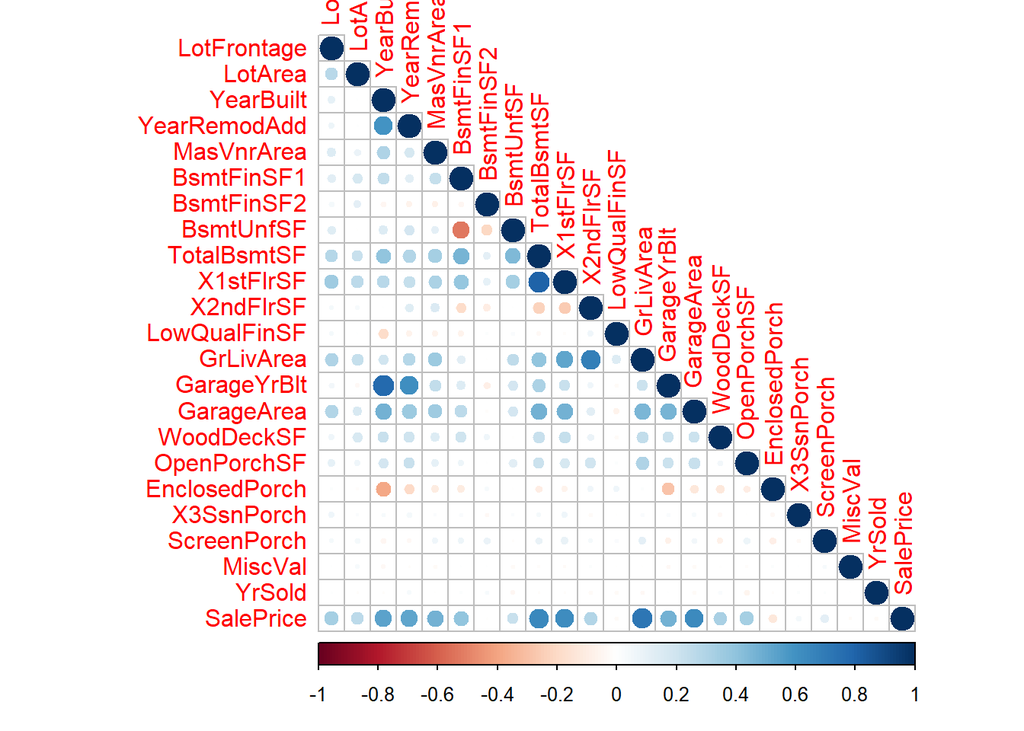

```r
CorTable <- cor(Filter(is.numeric, AmesTr))
corrplot::corrplot(CorTable, type = 'lower')
```

```r
numerics <- Filter(is.numeric, AmesTr)
usdm::vif(numerics)
```

```
##        Variables   VIF
## 1    LotFrontage 1.269
## 2        LotArea 1.209
## 3      YearBuilt 3.563
## 4   YearRemodAdd 1.954
## 5     MasVnrArea 1.366
## 6     BsmtFinSF1   Inf
## 7     BsmtFinSF2   Inf
## 8      BsmtUnfSF   Inf
## 9    TotalBsmtSF   Inf
## 10     X1stFlrSF   Inf
## 11     X2ndFlrSF   Inf
## 12  LowQualFinSF   Inf
## 13     GrLivArea   Inf
## 14   GarageYrBlt 3.069
## 15    GarageArea 1.900
## 16    WoodDeckSF 1.195
## 17   OpenPorchSF 1.180
## 18 EnclosedPorch 1.241
## 19    X3SsnPorch 1.016
## 20   ScreenPorch 1.092
## 21       MiscVal 1.007
## 22        YrSold 1.015
## 23     SalePrice 5.405
```

Again, collinearity issues exist with features related to square footage and basement, so we will treat them in this section just as we did previously.

# 2 Preparing Dummy Variables and Scaling Data

Next we perform more routine work, creating dummy variables and scaling the data. We want to end up with an abbreviated data set composed of the same useful features we worked with in the first part of the study.

```r
AmesTrTib <- as_tibble(AmesTr)
AmesTrTib
```

```
## # A tibble: 1,456 x 75
##    MSSubClass MSZoning LotFrontage LotArea Street LotShape LandContour
##    <fct>      <fct>          <int>   <int> <fct>  <fct>    <fct>
##  1 60         RL                65    8450 Pave   Reg      Lvl
##  2 20         RL                80    9600 Pave   Reg      Lvl
##  3 60         RL                68   11250 Pave   IR1      Lvl
##  4 70         RL                60    9550 Pave   IR1      Lvl
##  5 60         RL                84   14260 Pave   IR1      Lvl
##  6 50         RL                85   14115 Pave   IR1      Lvl
##  7 20         RL                75   10084 Pave   Reg      Lvl
##  8 60         RL                69   10382 Pave   IR1      Lvl
##  9 50         RM                51    6120 Pave   Reg      Lvl
## 10 190        RL                50    7420 Pave   Reg      Lvl
## # ... with 1,446 more rows, and 68 more variables: Utilities <fct>,
## #   LotConfig <fct>, LandSlope <fct>, Neighborhood <fct>,
## #   Condition1 <fct>, Condition2 <fct>, BldgType <fct>, HouseStyle <fct>,
## #   OverallQual <fct>, OverallCond <fct>, YearBuilt <int>,
## #   YearRemodAdd <int>, RoofStyle <fct>, RoofMatl <fct>,
## #   Exterior1st <fct>, Exterior2nd <fct>, MasVnrType <fct>,
## #   MasVnrArea <dbl>, ExterQual <fct>, ExterCond <fct>, Foundation <fct>,
## #   BsmtQual <fct>, BsmtCond <fct>, BsmtExposure <fct>,
## #   BsmtFinType1 <fct>, BsmtFinSF1 <dbl>, BsmtFinType2 <fct>,
## #   BsmtFinSF2 <dbl>, BsmtUnfSF <dbl>, TotalBsmtSF <dbl>, Heating <fct>,
## #   HeatingQC <fct>, CentralAir <fct>, Electrical <fct>, X1stFlrSF <int>,
## #   X2ndFlrSF <int>, LowQualFinSF <int>, GrLivArea <int>,
## #   BsmtFullBath <fct>, BsmtHalfBath <fct>, FullBath <fct>,
## #   HalfBath <fct>, BedroomAbvGr <fct>, KitchenAbvGr <fct>,
## #   KitchenQual <fct>, TotRmsAbvGrd <fct>, Functional <fct>,
## #   Fireplaces <fct>, FireplaceQu <fct>, GarageType <fct>,
## #   GarageYrBlt <int>, GarageFinish <fct>, GarageCars <fct>,
## #   GarageArea <dbl>, GarageQual <fct>, GarageCond <fct>,
## #   PavedDrive <fct>, WoodDeckSF <int>, OpenPorchSF <int>,
## #   EnclosedPorch <int>, X3SsnPorch <int>, ScreenPorch <int>,
## #   MiscVal <int>, MoSold <fct>, YrSold <int>, SaleType <fct>,
## #   SaleCondition <fct>, SalePrice <int>
```

```r
AmesTrDummy <- dummy_cols(AmesTrTib, remove_first_dummy = TRUE)
str(AmesTrDummy)
```

```
## Classes 'tbl_df', 'tbl' and 'data.frame':    1456 obs. of  366 variables:
##  $ MSSubClass           : Factor w/ 15 levels "20","30","40",..: 6 1 6 7 6 5 1 6 5 15 ...
##  $ MSZoning             : Factor w/ 5 levels "C (all)","FV",..: 4 4 4 4 4 4 4 4 5 4 ...
##  $ LotFrontage          : int  65 80 68 60 84 85 75 69 51 50 ...
##  $ LotArea              : int  8450 9600 11250 9550 14260 14115 10084 10382 6120 7420 ...
##  $ Street               : Factor w/ 2 levels "Grvl","Pave": 2 2 2 2 2 2 2 2 2 2 ...
##  $ LotShape             : Factor w/ 4 levels "IR1","IR2","IR3",..: 4 4 1 1 1 1 4 1 4 4 ...
##  $ LandContour          : Factor w/ 4 levels "Bnk","HLS","Low",..: 4 4 4 4 4 4 4 4 4 4 ...
##  $ Utilities            : Factor w/ 2 levels "AllPub","NoSeWa": 1 1 1 1 1 1 1 1 1 1 ...
##  $ LotConfig            : Factor w/ 5 levels "Corner","CulDSac",..: 5 3 5 1 3 5 5 1 5 1 ...
##  $ LandSlope            : Factor w/ 3 levels "Gtl","Mod","Sev": 1 1 1 1 1 1 1 1 1 1 ...
##  $ Neighborhood         : Factor w/ 25 levels "Blmngtn","Blueste",..: 6 25 6 7 14 12 21 17 18 4 ...
##  $ Condition1           : Factor w/ 9 levels "Artery","Feedr",..: 3 2 3 3 3 3 3 5 1 1 ...
##  $ Condition2           : Factor w/ 8 levels "Artery","Feedr",..: 3 3 3 3 3 3 3 3 3 1 ...
##  $ BldgType             : Factor w/ 5 levels "1Fam","2fmCon",..: 1 1 1 1 1 1 1 1 1 2 ...
```

[output cut: 87 more lines]

```r
match(c('SalePrice'), names(AmesTrDummy))
```

```
## [1] 75
```

```r
AmesTrDumNoTg <- AmesTrDummy[, -75]
AmesTrTarget <- AmesTrDummy[, 75]
names(Filter(is.factor, AmesTrDumNoTg))
```

```
##  [1] "MSSubClass"    "MSZoning"      "Street"        "LotShape"
##  [5] "LandContour"   "Utilities"     "LotConfig"     "LandSlope"
##  [9] "Neighborhood"  "Condition1"    "Condition2"    "BldgType"
## [13] "HouseStyle"    "OverallQual"   "OverallCond"   "RoofStyle"
## [17] "RoofMatl"      "Exterior1st"   "Exterior2nd"   "MasVnrType"
## [21] "ExterQual"     "ExterCond"     "Foundation"    "BsmtQual"
## [25] "BsmtCond"      "BsmtExposure"  "BsmtFinType1"  "BsmtFinType2"
## [29] "Heating"       "HeatingQC"     "CentralAir"    "Electrical"
## [33] "BsmtFullBath"  "BsmtHalfBath"  "FullBath"      "HalfBath"
## [37] "BedroomAbvGr"  "KitchenAbvGr"  "KitchenQual"   "TotRmsAbvGrd"
## [41] "Functional"    "Fireplaces"    "FireplaceQu"   "GarageType"
## [45] "GarageFinish"  "GarageCars"    "GarageQual"    "GarageCond"
## [49] "PavedDrive"    "MoSold"        "SaleType"      "SaleCondition"
```

```r
dropCols <- c("MSSubClass", "MSZoning", "Street", "LotShape", "LandContour",
              "Utilities", "LotConfig", "LandSlope", "Neighborhood", "Condition1",
              "Condition2", "BldgType", "HouseStyle", "OverallQual", "OverallCond",
              "RoofStyle", "RoofMatl", "Exterior1st", "Exterior2nd", "MasVnrType",
              "ExterQual", "ExterCond", "Foundation", "BsmtQual", "BsmtCond",
              "BsmtExposure", "BsmtFinType1", "BsmtFinType2", "Heating", "HeatingQC",
              "CentralAir", "Electrical", "BsmtFullBath", "BsmtHalfBath", "FullBath",
              "HalfBath", "BedroomAbvGr", "KitchenAbvGr", "KitchenQual", "TotRmsAbvGrd",
              "Functional", "Fireplaces", "FireplaceQu", "GarageType", "GarageFinish",
              "GarageCars", "GarageQual", "GarageCond", "PavedDrive","MoSold",
              "SaleType", "SaleCondition")
AmesTrDumNoTg <- AmesTrDumNoTg %>% dplyr::select(-one_of(dropCols))
AmesTrDumwTg <- cbind(AmesTrTarget, AmesTrDumNoTg)
dim(AmesTrDumNoTg)
```

```
## [1] 1456  313
```

```r
dim(AmesTrDumwTg)
```

```
## [1] 1456  314
```

```r
nan_sums <- colSums(is.na(AmesTrDumNoTg))
nan_sums[nan_sums > 0]
```

```
## named numeric(0)
```

```r
sum(is.empty(AmesTrDumNoTg))
```

```
## [1] 407986
```

```r
AmesTrDumScale <- scale(AmesTrDumNoTg, center = TRUE, scale = TRUE)
AmesTrDumScaleDF <- as.tibble(AmesTrDumScale)
AmesTrDumScaleDF <- cbind(AmesTrTarget, AmesTrDumScaleDF)

match(c('SalePrice', 'GrLivArea', 'TotalBsmtSF', 'RoofMatl_ClyTile',
        'YearBuilt', 'Condition2_PosN', 'OverallQual_10', 'SaleType_New',
        'Neighborhood_StoneBr', 'LotArea', 'Neighborhood_NridgHt',
        'GarageArea', 'HouseStyle_1Story', 'Neighborhood_Crawfor', 'KitchenQual_Ex',
        'Neighborhood_NoRidge', 'Fireplaces_2'), names(AmesTrDumScaleDF))
```

```
##  [1]   1  14  10  NA   4  92 111 302  73   3  65  16  99  57 239  58 259
```

```r
AmesTrDumScaleDFShort <- AmesTrDumScaleDF[, c(1, 14, 10, 4, 92, 111, 302, 73, 3, 65,
                                              16, 99, 57, 239, 58, 259)]
```

There is one difference between this feature set and the previous one. The feature *RoofMatl_ClyTile* is missing from this set. This is because that type of material is not found in the observations used in the *train.csv* file, though it is in the combined data file. Since it is missing now we will just drop the feature from our current list, reducing it from 16 to 15.

We need to create a couple objects and a function we will call upon later in the analysis, so let’s take a minute to do that.

```r
AmesTrDumScaleDFShort$id <- 1:nrow(AmesTrDumScaleDFShort)
lm.train <- AmesTrDumScaleDFShort %>% sample_frac(0.5)
lm.test <- anti_join(AmesTrDumScaleDFShort, lm.train, by = 'id')

predict.regsubsets <- function(object, newdata, id, ...) {
        form = as.formula(object$call [[2]])
        mat = model.matrix(form, newdata)
        coefi = coef(object, id = id)
        xvars = names(coefi)
        mat[, xvars] %*% coefi
}
```

# 3 Using *k-fold* Cross Validation Feature Selection

We are ready to resume the analysis.

In the first section we performed some feature selection using a couple different regression methods. Next we will continue with a *k-fold* cross validation, in which subsets are selected from each of the *k* training sets available. There are 15 features to work with so *k* will be set to that number. Our purpose here is not so much selecting a new set of features as it is to use this method to confirm the feature set we selected earlier.

```r
k = 15
set.seed(805)
folds <- sample(1:k, nrow(AmesTrDumScaleDFShort), replace = TRUE)
cv.errors <- matrix(NA, k, 15, dimnames = list(NULL, paste(1:15)))
for (j in 1:k) {
        best.fit = regsubsets(SalePrice ~ ., data = AmesTrDumScaleDFShort[folds != j, ],
                              nvmax = 16)
        for (i in 1:15) {
                pred = predict.regsubsets(best.fit, AmesTrDumScaleDFShort[folds == j, ], id = i)
                cv.errors[j, i] =  mean((AmesTrDumScaleDFShort$SalePrice[folds == j] - pred)^2)
        }
}
```

```
## Reordering variables and trying again:
```

Next we calculate the cross validation errors, average them, and plot results against the number of variables, the *k-folds* we are working with. We can see 14 or 15 features minimize error. Cross validation indicates the number of features we are working with is appropriate. We will calculate the coefficients for the features at that level. We can use these to validate our earlier findings and build a model.

```r
mean.cv.errors <- apply(cv.errors, 2, mean)
mean.cv.errors
```

```
##         1         2         3         4         5         6         7
## 2.849e+09 1.941e+09 1.501e+09 1.221e+09 1.149e+09 1.127e+09 1.076e+09
##         8         9        10        11        12        13        14
## 1.045e+09 1.022e+09 1.015e+09 9.696e+08 8.935e+08 8.847e+08 8.784e+08
##        15
## 8.814e+08
```

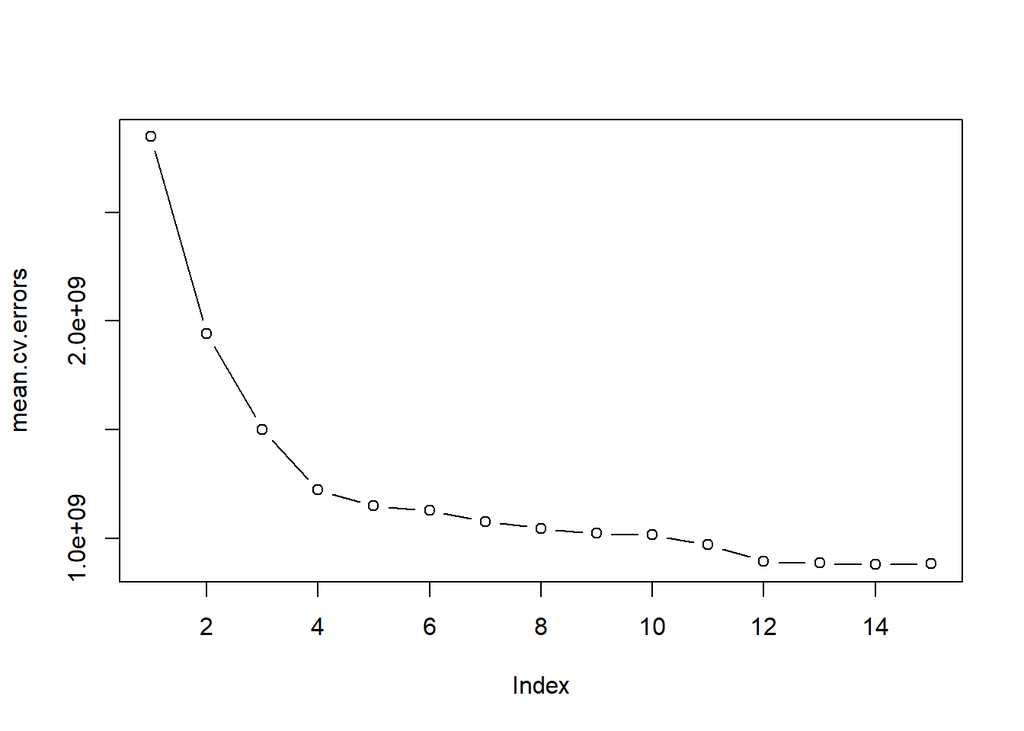

```r
plot(mean.cv.errors, type = 'b')
```

```r
regbest <- regsubsets(SalePrice ~ ., data = AmesTrDumScaleDFShort, nvmax = 18)
coef(regbest, 15)
```

```
##          (Intercept)            GrLivArea          TotalBsmtSF
##               180151                28807                13766
##            YearBuilt      Condition2_PosN       OverallQual_10
##                18744                -2300                 7747
##         SaleType_New Neighborhood_StoneBr              LotArea
##                 6578                 7016                 6748
## Neighborhood_NridgHt           GarageArea    HouseStyle_1Story
##                 6966                 9158                -1330
## Neighborhood_Crawfor       KitchenQual_Ex Neighborhood_NoRidge
##                 7235                11440                 7156
##         Fireplaces_2
##                 3452
```

# 4 Creating a Ridge Regression Analysis

```r
xx <- model.matrix(SalePrice ~ ., data = AmesTrDumScaleDFShort)[, -1]
yy <- AmesTrDumScaleDFShort$SalePrice
grid <- 10^seq(10, -2, length = 100)
ridge.mod <- glmnet(xx, yy, alpha = 0, lambda = grid, standardize = FALSE)
ridge.mod
```

```
##
## Call:  glmnet(x = xx, y = yy, alpha = 0, lambda = grid, standardize = FALSE)
##
##        Df     %Dev   Lambda
##   [1,] 16 0.000657 1.00e+10
##   [2,] 16 0.000709 7.56e+09
##   [3,] 16 0.000756 5.72e+09
##   [4,] 16 0.000800 4.33e+09
##   [5,] 16 0.000845 3.27e+09
##   [6,] 16 0.000894 2.48e+09
##   [7,] 16 0.000952 1.87e+09
##   [8,] 16 0.001020 1.42e+09
##   [9,] 16 0.001110 1.07e+09
##  [10,] 16 0.001230 8.11e+08
##  [11,] 16 0.001390 6.14e+08
```

[output cut: 89 more lines]

```r
dim(coef(ridge.mod))
```

```
## [1]  17 100
```

```r
ridge.mod$lambda[32]
```

```
## [1] 1747528
```

```r
coef(ridge.mod)[, 32]
```

```
##          (Intercept)            GrLivArea          TotalBsmtSF
##           183456.207             2168.882             1906.619
##            YearBuilt      Condition2_PosN       OverallQual_10
##             1587.855              182.718              949.709
##         SaleType_New Neighborhood_StoneBr              LotArea
##             1099.282              672.882              799.195
## Neighborhood_NridgHt           GarageArea    HouseStyle_1Story
##             1214.848             1873.151             -187.811
## Neighborhood_Crawfor       KitchenQual_Ex Neighborhood_NoRidge
##              256.241             1455.377              872.575
##         Fireplaces_2                   id
##              577.165               -4.537
```

Due to the structure of the grid, the ridge model creates a 17 x 100 matrix of values for model coefficients. Each vector is associated with a specific lambda value. We can identify lambda at any step in the matrix and calculate the coefficients associated with that lambda. The results are available above.

We can use that information to calculate the *RMSE* for the ridge at that particular lambda. Though low, this is not necessarily the most appropriate *RMSE*. We are tuning the lambda value. If we tune properly we will get the most appropriate *RMSE*, which isn’t always the lowest *RMSE* value.

```r
sqrt(sum(coef(ridge.mod)[-1, 32]^2))
```

```
## [1] 4732
```

We can select any lambda position and find coefficients there, as well. In this way, we can begin to find the right level of lambda for our problem. The lower the value of lambda, the larger our coefficients are going to be. For example, let’s choose the lambda at the 60th position.

```r
ridge.mod$lambda[60]
```

```
## [1] 705.5
```

```r
coef(ridge.mod)[, 60]
```

```
##          (Intercept)            GrLivArea          TotalBsmtSF
##           181496.514            28415.988            13863.766
##            YearBuilt      Condition2_PosN       OverallQual_10
##            18539.686            -2260.193             7716.568
##         SaleType_New Neighborhood_StoneBr              LotArea
##             6588.507             6976.984             6700.982
## Neighborhood_NridgHt           GarageArea    HouseStyle_1Story
##             6910.318             9338.398            -1489.064
## Neighborhood_Crawfor       KitchenQual_Ex Neighborhood_NoRidge
##             7200.123            11428.311             7194.538
##         Fireplaces_2                   id
##             3453.618               -1.847
```

```r
sqrt(sum(coef(ridge.mod)[-1, 60]^2))
```

```
## [1] 43913
```

```r
predict(ridge.mod, s = 50, type = 'coefficients')[1:16, ]
```

```
##          (Intercept)            GrLivArea          TotalBsmtSF
##               181494                28782                13756
##            YearBuilt      Condition2_PosN       OverallQual_10
##                18724                -2291                 7749
##         SaleType_New Neighborhood_StoneBr              LotArea
##                 6572                 6994                 6719
## Neighborhood_NridgHt           GarageArea    HouseStyle_1Story
##                 6901                 9208                -1334
## Neighborhood_Crawfor       KitchenQual_Ex Neighborhood_NoRidge
##                 7260                11461                 7177
##         Fireplaces_2
##                 3428
```

We see the lower lambda increases the size of the coefficients and, since the lambda penalty is smaller, a larger *RMSE* of 43,913 results.

Now, we will split the *train.csv* data file into training and test sets to assess how well the model behaves. The *RMSE* is the last line of output.

```r
set.seed(805)
train <-  sample(1:nrow(xx), nrow(xx) / 2)
test <-  (-train)
yy.test <-  yy[test]
ridge.mod <- glmnet(xx[train, ], yy[train], alpha = 0, lambda = grid, thresh = 1e-12)
ridge.pred <- predict(ridge.mod, s = 4, newx = xx[test, ])
mean((ridge.pred - yy.test)^2)
```

```
## [1] 1.003e+09
```

```r
ridge.RMSE <- sqrt(mean((ridge.pred - yy.test)^2))
ridge.RMSE
```

```
## [1] 31672
```

*RMSE* comes in at 31,672. This represents a definite improvement over the regression value of 193,543 and will be the second best result to come out of the analysis.

What remains is to find the best lambda value for the model. To do this, we will use cross validation to tune model parameters. We will find that the best lambda is 6235 which yields an *RMSE* of 31,376. Ridge regression outperforms least squares.

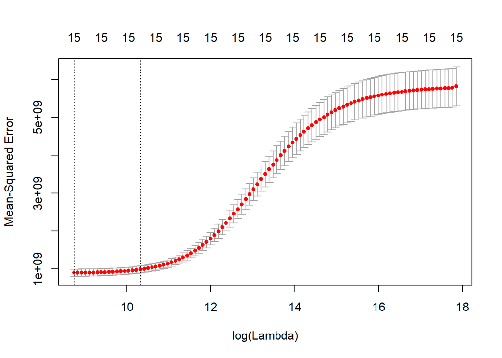

```r
set.seed(805)
cv.out <- cv.glmnet(xx[train, ], yy[train], alpha = 0)
plot(cv.out)
```

```r
bestlam <- cv.out$lambda.min
bestlam
```

```
## [1] 6235
```

```r
ridge.pred <- predict(ridge.mod, s = bestlam, newx = xx[test, ])
mean((ridge.pred - yy.test)^2)
```

```
## [1] 984468811
```

```r
bestRidge.RMSE <- sqrt(mean((ridge.pred - yy.test)^2))
bestRidge.RMSE
```

```
## [1] 31376
```

```r
out <- glmnet(xx, yy, alpha = 0)
predict(out, type = 'coefficients', s = bestlam)[1:15, ]
```

```
##          (Intercept)            GrLivArea          TotalBsmtSF
##               181418                26112                14258
##            YearBuilt      Condition2_PosN       OverallQual_10
##                17247                -2011                 7467
##         SaleType_New Neighborhood_StoneBr              LotArea
##                 6686                 6816                 6556
## Neighborhood_NridgHt           GarageArea    HouseStyle_1Story
##                 6984                10144                -2259
## Neighborhood_Crawfor       KitchenQual_Ex Neighborhood_NoRidge
##                 6708                11163                 7257
```

The graph above plots the cross validation results of the MSE against the log of the lambda value to show where the best lamba lies.

# 5 Creating the Lasso

As with the ridge regression, we start by defining the model and examining its output.

The first graph demonstrates how the application of the penalty impacts the coefficients of the model. The higher the penalty, it seems, the lower the value of the coefficients. The second graph is the log of lambda plot (as above) for the lasso.

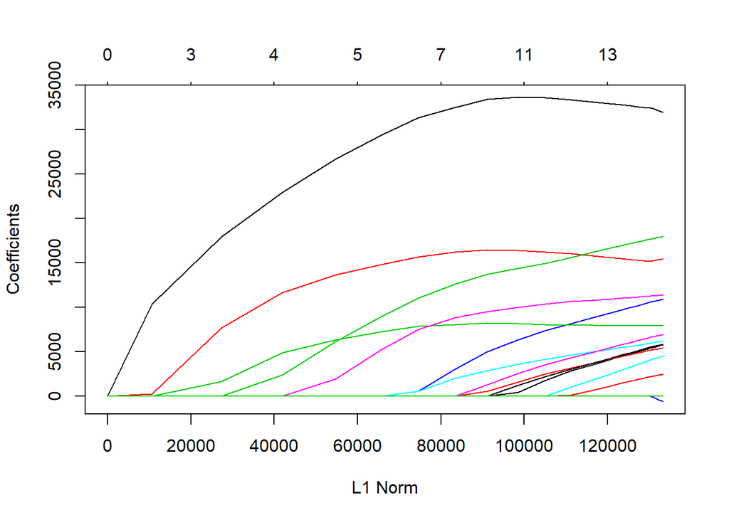

```r
lasso.mod <- glmnet(xx[train, ], yy[train], alpha = 1, lambda = grid)
plot(lasso.mod)
```

```r
set.seed(805)
cv.out <- cv.glmnet(xx[train, ], yy[train], alpha = 1)
```

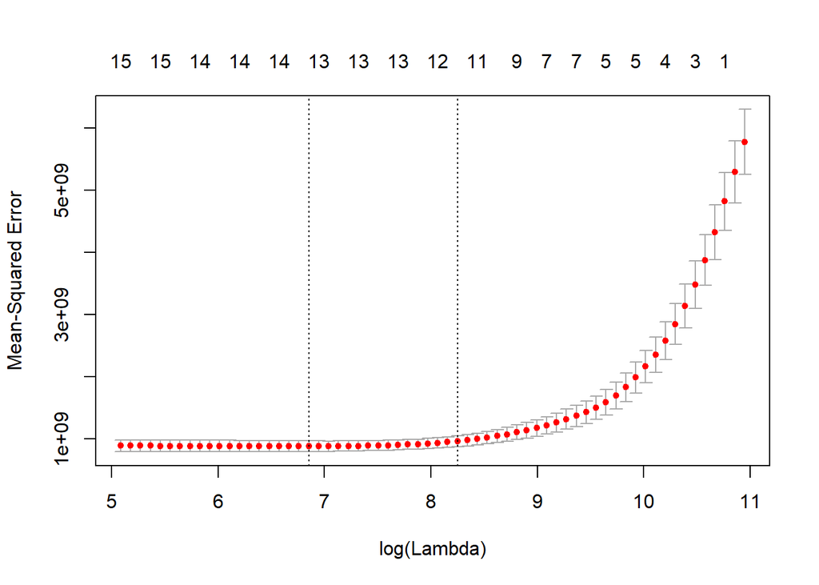

```r
plot(cv.out)
```

We use a similar process as before to define the best lambda for tuning the lasso model. A lambda of 947.7 yields an *RMSE* of 31,877. This is very similar to the *RMSE* from the ridge but not an improvement.

```r
bestlam <- cv.out$lambda.min
bestlam
```

```
## [1] 947.7
```

```r
lasso.pred <- predict(lasso.mod, s = bestlam, newx = xx[test, ])
mean((lasso.pred - yy.test)^2)
```

```
## [1] 1.016e+09
```

```r
lasso.RMSE <- sqrt(mean((lasso.pred - yy.test)^2))
lasso.RMSE
```

```
## [1] 31877
```

The coefficients for the lasso model associated with the best lambda are given below. We suppress the lengthy output but the reviewer can examine that by changing the code.

```r
#out <-  glmnet(xx, yy, alpha = 1, lambda = grid)
lasso.coef <-  predict(out, type = 'coefficients', s = bestlam)[1:15, ]
lasso.coef
```

```
##          (Intercept)            GrLivArea          TotalBsmtSF
##               181426                26362                14233
##            YearBuilt      Condition2_PosN       OverallQual_10
##                17393                -2042                 7497
##         SaleType_New Neighborhood_StoneBr              LotArea
##                 6677                 6838                 6574
## Neighborhood_NridgHt           GarageArea    HouseStyle_1Story
##                 6977                10062                -2190
## Neighborhood_Crawfor       KitchenQual_Ex Neighborhood_NoRidge
##                 6768                11196                 7255
```

# 6 Performing Principle Components Regression

Principle Components Regression (PCR) is similar to Principle Components Analysis (PCA) except we can use the PCR model to predict *SalePrice* in our data. We set the function to perform a cross validation, which involves a default of 10-fold cross validation error. We see in the summary that PCR creates a series of principle components and calculates the CV score for each. The score will be visualized in the validation plot that follows.

```r
set.seed(805)
pcr.fit <- pcr(SalePrice ~ ., data = AmesTrDumScaleDFShort, subset = train,
               validation = 'CV')
summary(pcr.fit)
```

```
## Data:    X dimension: 728 16
##  Y dimension: 728 1
## Fit method: svdpc
## Number of components considered: 16
##
## VALIDATION: RMSEP
## Cross-validated using 10 random segments.
##        (Intercept)  1 comps  2 comps  3 comps  4 comps  5 comps  6 comps
## CV           76286    76312    35260    32018    32065    31663    30902
## adjCV        76286    76305    35142    31899    31954    31546    30874
##        7 comps  8 comps  9 comps  10 comps  11 comps  12 comps  13 comps
## CV       30877    31000    30835     30634     31110     30851     30783
## adjCV    30808    30955    30743     30553     31037     31083     30534
##        14 comps  15 comps  16 comps
## CV        29689     29664     58373
## adjCV     29627     29531     39624
##
## TRAINING: % variance explained
##              1 comps  2 comps  3 comps  4 comps  5 comps  6 comps  7 comps
## X          9.999e+01    99.99   100.00    100.0    100.0   100.00   100.00
## SalePrice  6.718e-05    79.71    83.08     83.2     83.9    84.29    84.46
##            8 comps  9 comps  10 comps  11 comps  12 comps  13 comps
## X           100.00    100.0    100.00    100.00    100.00    100.00
## SalePrice    84.47     84.8     84.93     84.94     84.94     85.86
##            14 comps  15 comps  16 comps
## X            100.00    100.00    100.00
## SalePrice     86.51     86.93     86.97
```

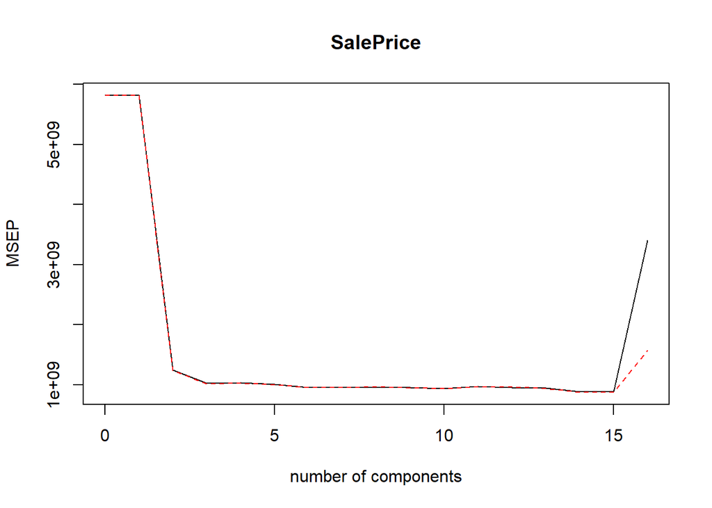

```r
validationplot(pcr.fit, val.type = 'MSEP')
```

```r
pcr.pred <- predict(pcr.fit, xx[test, ], ncomp = 16)
#pcr.pred
mm <- mean((pcr.pred - yy.test)^2)
pcr.RMSE <- sqrt(mm)
pcr.RMSE
```

```
## [1] 8.01e+19
```

```r
pcr.fit <- pcr(yy ~ xx, ncomp = 16)
summary(pcr.fit)
```

```
## Data:    X dimension: 1456 16
##  Y dimension: 1456 1
## Fit method: svdpc
## Number of components considered: 16
## TRAINING: % variance explained
##      1 comps  2 comps  3 comps  4 comps  5 comps  6 comps  7 comps
## X   99.99152    99.99    99.99   100.00   100.00    100.0   100.00
## yy   0.07542    76.73    81.94    82.57    82.88     83.7    83.87
##     8 comps  9 comps  10 comps  11 comps  12 comps  13 comps  14 comps
## X    100.00   100.00    100.00    100.00    100.00    100.00    100.00
## yy    84.21    84.25     84.28     84.29     84.41     84.41     84.45
##     15 comps  16 comps
## X     100.00    100.00
## yy     85.35     85.67
```

# 7 Fitting a Decision Tree

Dcision trees are another method to select features and develop a predictive model. The first tree we work with is designed just to indicate if the predicted *SalePrice* is above or below the median of 163,000. In the summary and plot of the resulting tree, notice that the model chooses only four significant features, as opposed to the 16 features suggested by the linear regression methods used in the first part of the study.

```r
DTAmes <- AmesTrDumScaleDFShort
median(DTAmes$SalePrice)
```

```
## [1] 163000
```

```r
High <- ifelse(DTAmes$SalePrice < 162999, 'No', 'Yes')
DTAmes <- data.frame(DTAmes, High)
tree.DTAmes <- tree::tree(High ~ . -SalePrice, DTAmes)
summary(tree.DTAmes)
```

```
##
## Classification tree:
## tree::tree(formula = High ~ . - SalePrice, data = DTAmes)
## Variables actually used in tree construction:
## [1] "YearBuilt"   "GrLivArea"   "LotArea"     "TotalBsmtSF"
## Number of terminal nodes:  10
## Residual mean deviance:  0.474 = 686 / 1450
## Misclassification error rate: 0.0955 = 139 / 1456
```

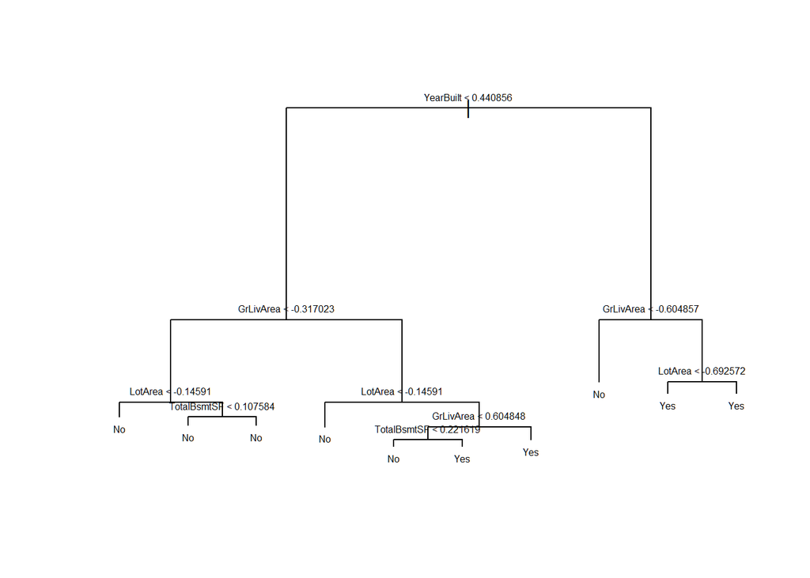

```r
plot(tree.DTAmes)
text(tree.DTAmes, pretty = 0, cex = 0.5)
```

We can assess the accuracy of this simple decision tree model by counting the number of predictions it gets right relative to the actual data in the test set. The result is 88.6% accuracy on the basis of a binary decision.

```r
tree.DTAmes
```

```
## node), split, n, deviance, yval, (yprob)
##       * denotes terminal node
##
##  1) root 1456 2000 Yes ( 0.50 0.50 )
##    2) YearBuilt < 0.440856 882 1000 No ( 0.76 0.24 )
##      4) GrLivArea < -0.317023 490  200 No ( 0.95 0.05 )
##        8) LotArea < -0.14591 299    0 No ( 1.00 0.00 ) *
##        9) LotArea > -0.14591 191  100 No ( 0.88 0.12 )
##         18) TotalBsmtSF < 0.107584 139   50 No ( 0.96 0.04 ) *
##         19) TotalBsmtSF > 0.107584 52   70 No ( 0.67 0.33 ) *
##      5) GrLivArea > -0.317023 392  500 No ( 0.51 0.49 )
##       10) LotArea < -0.14591 118  100 No ( 0.83 0.17 ) *
##       11) LotArea > -0.14591 274  400 Yes ( 0.37 0.63 )
##         22) GrLivArea < 0.604848 163  200 No ( 0.52 0.48 )
##           44) TotalBsmtSF < 0.221619 85  100 No ( 0.68 0.32 ) *
##           45) TotalBsmtSF > 0.221619 78  100 Yes ( 0.33 0.67 ) *
##         23) GrLivArea > 0.604848 111  100 Yes ( 0.15 0.85 ) *
##    3) YearBuilt > 0.440856 574  400 Yes ( 0.11 0.89 )
##      6) GrLivArea < -0.604857 53   50 No ( 0.83 0.17 ) *
##      7) GrLivArea > -0.604857 521  100 Yes ( 0.03 0.97 )
##       14) LotArea < -0.692572 34   40 Yes ( 0.29 0.71 ) *
##       15) LotArea > -0.692572 487   70 Yes ( 0.01 0.99 ) *
```

```r
set.seed(805)
train <- sample(1:nrow(DTAmes), 728)
Ames.test <- DTAmes[-train,]
High.test <- High[-train]
tree.Ames <- tree(High ~. -SalePrice, DTAmes, subset = train)
tree.pred <- predict(tree.Ames, Ames.test, type = 'class')
table(tree.pred, High.test)
```

```
##          High.test
## tree.pred  No Yes
##       No  321  47
##       Yes  36 324
```

```r
(321 + 324) / 728
```

```
## [1] 0.886
```

We can use cross validation with decision trees, as well, to determine the optimal number of branches the tree should contain to minimize error. This is called “pruning” a decision stree. The cross validation results include the number of terminal nodes for each tree (size), the error rate associated with each (dev), and the cost-complexity parameter (k). We see in the following results that the tree with seven terminal nodes results in the lowest error rate (81).

```r
set.seed(805)
cv.Ames <- cv.tree(tree.Ames, FUN = prune.misclass)
names(cv.Ames)
```

```
## [1] "size"   "dev"    "k"      "method"
```

```r
cv.Ames
```

```
## $size
## [1] 11  8  7  5  4  2  1
##
## $dev
## [1]  87  87  81  88 111 126 358
##
## $k
## [1]  -Inf   0.0   2.0   7.5  16.0  20.0 230.0
##
## $method
## [1] "misclass"
##
## attr(,"class")
## [1] "prune"         "tree.sequence"
```

We can plot the error rate against both *size* and *k*. Again, we see 7 terminal nodes is the most appropriate size for the decision tree model.

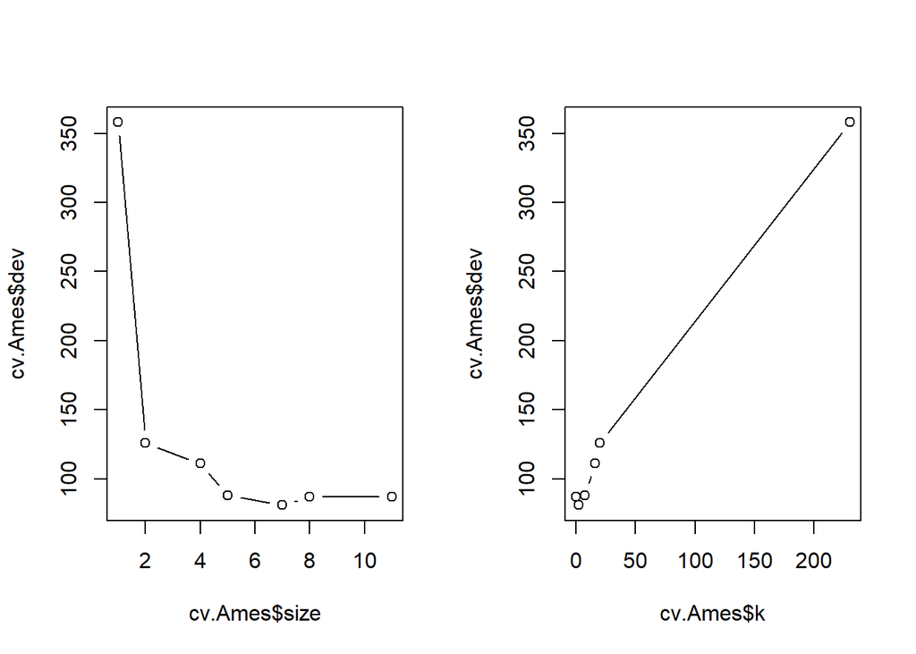

```r
par(mfrow = c(1, 2))
plot(cv.Ames$size, cv.Ames$dev, type = 'b')
plot(cv.Ames$k, cv.Ames$dev, type = 'b')
```

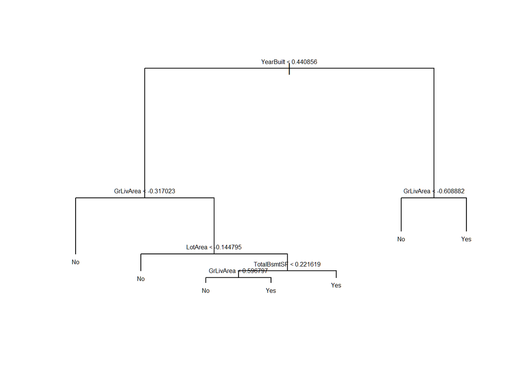

```r
prune.Ames <- prune.misclass(tree.Ames, best = 7)
plot(prune.Ames)
text(prune.Ames, pretty = 0, cex = 0.5)
```

```r
tree.pred <- predict(prune.Ames, Ames.test, type = 'class')
table(tree.pred, High.test)
```

```
##          High.test
## tree.pred  No Yes
##       No  322  49
##       Yes  35 322
```

```r
(322 + 322) / 728
```

```
## [1] 0.8846
```

# 8 Fitting a Regression Tree

Our exploration of decision trees leads us to a point where we can fit a regression tree to the *Ames* data and calculate the *RMSE*. We start by deleting two unnecessary columns from the data, the *id* and *High* columns, and training the data against the test target *SalePrice*. Here, the tree utilizes just five features: *YearBuilt*, *GrLivArea*, *TotalBsmtSF*, *GarageArea*, and *KitchenQual_Ex*.

```r
DTRAmes <- DTAmes[, -c(17, 18)]
set.seed(805)
train <- sample(1:nrow(DTRAmes), nrow(DTRAmes) / 2)
tree.DTRAmes <- tree(SalePrice ~ ., DTRAmes, subset = train)
summary(tree.DTRAmes)
```

```
##
## Regression tree:
## tree(formula = SalePrice ~ ., data = DTRAmes, subset = train)
## Variables actually used in tree construction:
## [1] "YearBuilt"      "GrLivArea"      "TotalBsmtSF"    "GarageArea"
## [5] "KitchenQual_Ex"
## Number of terminal nodes:  14
## Residual mean deviance:  1.15e+09 = 8.2e+11 / 714
## Distribution of residuals:
##    Min. 1st Qu.  Median    Mean 3rd Qu.    Max.
## -128000  -20600    -765       0   17600  168000
```

The fitted tree looks like this:

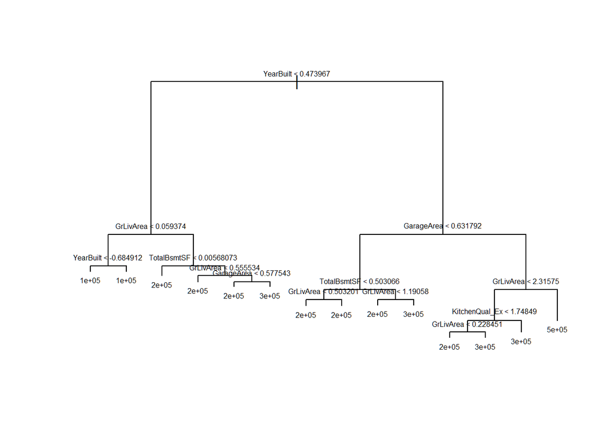

```r
plot(tree.DTRAmes)
text(tree.DTRAmes, pretty = 0, cex = 0.5)
```

We can run a cross validation on the errors given by the tree to find the optimal number of terminal nodes. It looks like the fitted tree requires 14 terminal nodes to minimize error.

```r
cv.DTRAmes <- cv.tree(tree.DTRAmes)
cv.DTRAmes
```

```
## $size
##  [1] 14 13 12 11 10  9  8  7  6  5  4  3  2  1
##
## $dev
##  [1] 1.417e+12 1.529e+12 1.566e+12 1.566e+12 1.575e+12 1.607e+12 1.607e+12
##  [8] 1.776e+12 1.801e+12 1.785e+12 2.489e+12 2.489e+12 2.634e+12 4.237e+12
##
## $k
##  [1]      -Inf 4.963e+10 5.386e+10 5.388e+10 5.526e+10 6.158e+10 6.195e+10
##  [8] 9.891e+10 1.026e+11 1.186e+11 3.135e+11 3.200e+11 5.607e+11 1.554e+12
##
## $method
## [1] "deviance"
##
## attr(,"class")
## [1] "prune"         "tree.sequence"
```

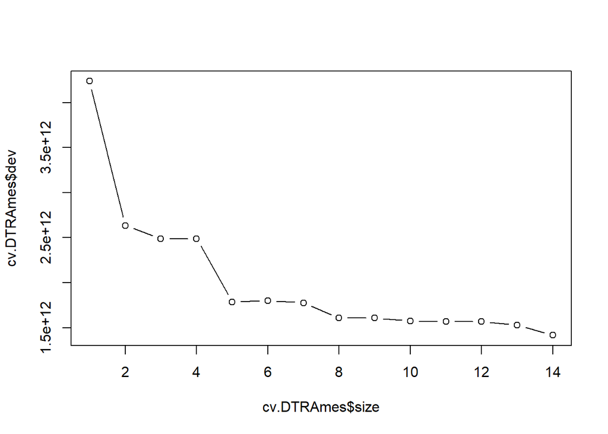

```r
plot(cv.DTRAmes$size, cv.DTRAmes$dev, type = 'b')
```

So we prune the tree back to its optimal level and take a look at it.

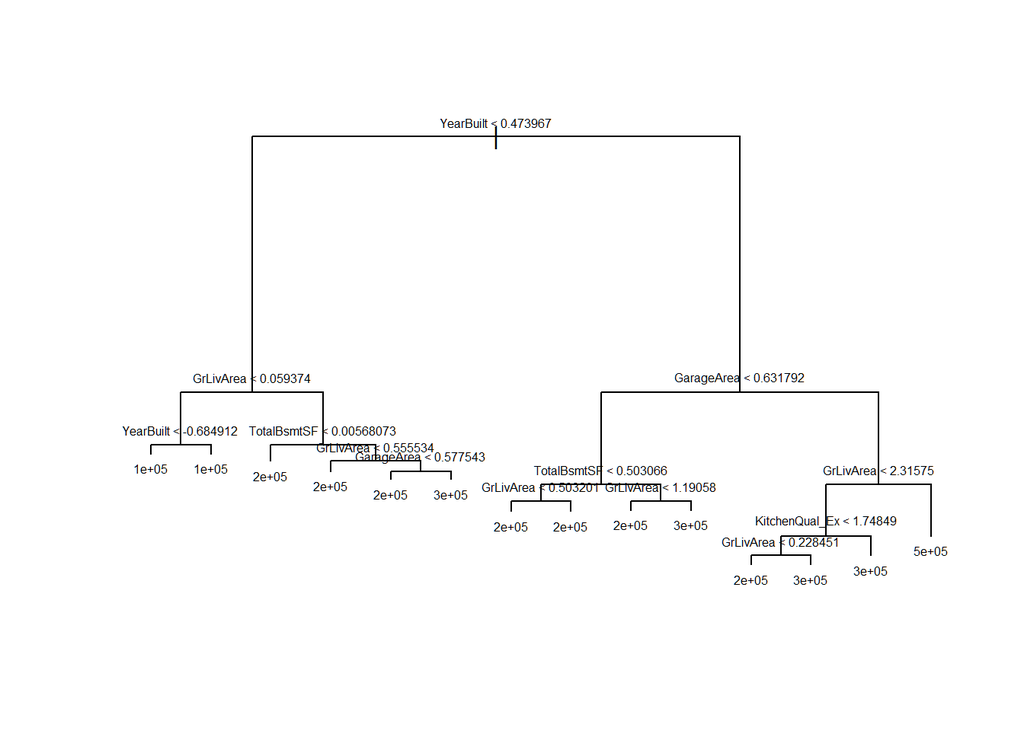

```r
prune.DTRAmes <- prune.tree(tree.DTRAmes, best = 14)
plot(prune.DTRAmes)
text(prune.DTRAmes, pretty = 0, cex = 0.5)
```

Now, we can use the fitted regression tree model to make predictions about *SalePrice*. We plot the results and find the *RMSE* is 44,719. This is much better than the benchmark but still not an improvement over the ridge regression or PCR algorithms.

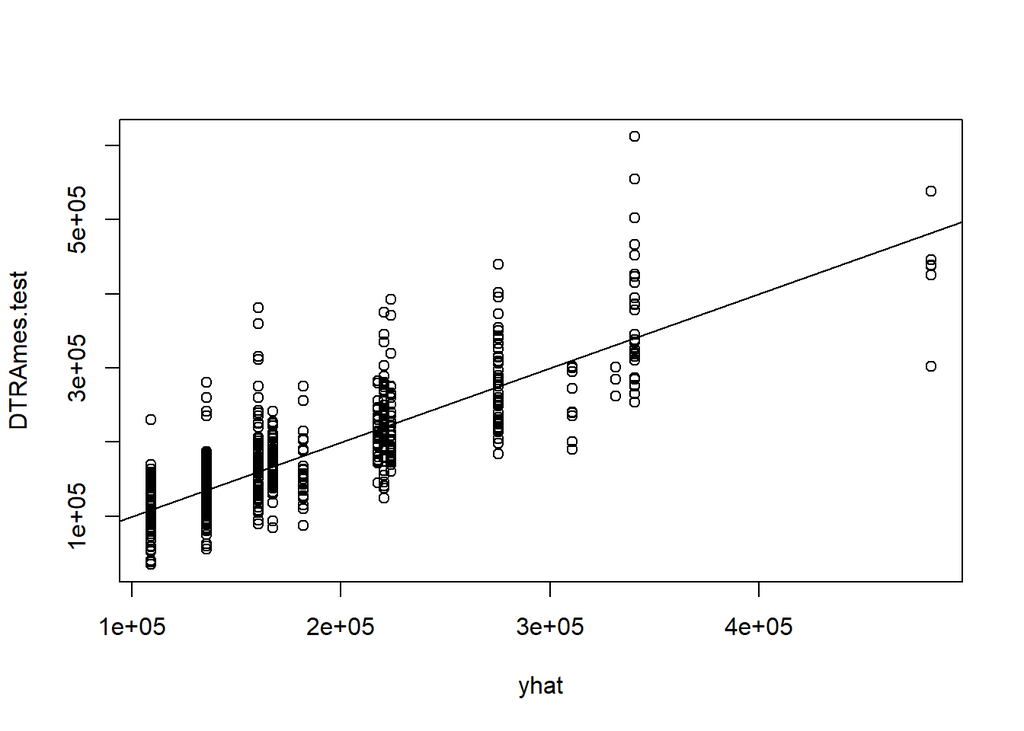

```r
yhat <- predict(prune.DTRAmes, newdata = DTRAmes[-train, ])
DTRAmes.test <- DTRAmes[-train, 'SalePrice']
plot(yhat, DTRAmes.test)
abline(0, 1)
```

```r
mean((yhat - DTRAmes.test)^2)
```

```
## [1] 2e+09
```

```r
DTR.RMSE <- sqrt(mean((yhat - DTRAmes.test)^2))
DTR.RMSE
```

```
## [1] 44719
```

# 9 Creating a Random Forest Analysis (with Bagging)

Instead of using a single specimen, we can build a “forest” of decision trees and average their results. This is known as “ensemble” modelling. “Bagging” is a special kind of random forest model, in which *m = p*. That is, in which the size of the sample predictors (*m*) is equal to the size of the full set of predictors (*p*).

At this stage of the analysis, we can build the bagging model fairly quickly and examine its results. This model generates a “forest” of 500 decision trees and averages the results. In doing so, it achieves an *adjusted R<sup>2</sup>* of 83.2.

```r
set.seed(805)
bag.DTRAmes <- randomForest(SalePrice ~ ., data = DTRAmes, subset = train,
                            mtry = 18, importance = TRUE)
bag.DTRAmes
```

```
##
## Call:
##  randomForest(formula = SalePrice ~ ., data = DTRAmes, mtry = 18,      importance = TRUE, subset = train)
##                Type of random forest: regression
##                      Number of trees: 500
## No. of variables tried at each split: 15
##
##           Mean of squared residuals: 974450404
##                     % Var explained: 83.21
```

We use the model to generate predictions, plot the results, and calculate an *RMSE* of 32,047. This is comparable to the ridge regression but still not an improvement.

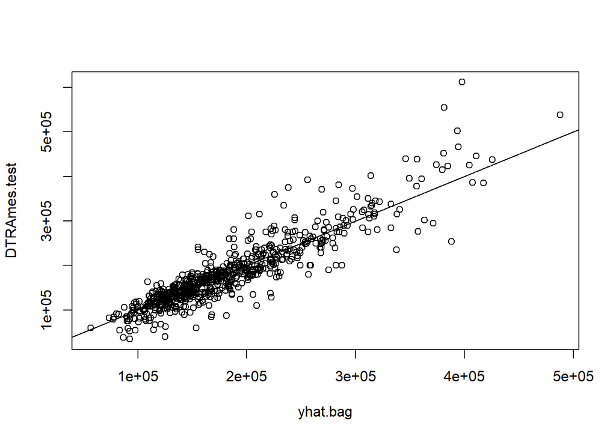

```r
yhat.bag <- predict(bag.DTRAmes, newdata = DTRAmes[-train, ])
plot(yhat.bag, DTRAmes.test)
abline(0, 1)
```

```r
mean((yhat.bag - DTRAmes.test)^2)
```

```
## [1] 1.027e+09
```

```r
bag.RMSE <- sqrt(mean((yhat.bag - DTRAmes.test)^2))
bag.RMSE
```

```
## [1] 32047
```

# 10 Creating a Random Forest Analysis (Standard)

```r
set.seed(805)
rf.DTRAmes <- randomForest(SalePrice ~ ., data = DTRAmes, subset = train,
                           mtry = 6, importance = TRUE)
rf.DTRAmes
```

```
##
## Call:
##  randomForest(formula = SalePrice ~ ., data = DTRAmes, mtry = 6,      importance = TRUE, subset = train)
##                Type of random forest: regression
##                      Number of trees: 500
## No. of variables tried at each split: 6
##
##           Mean of squared residuals: 938119080
##                     % Var explained: 83.84
```

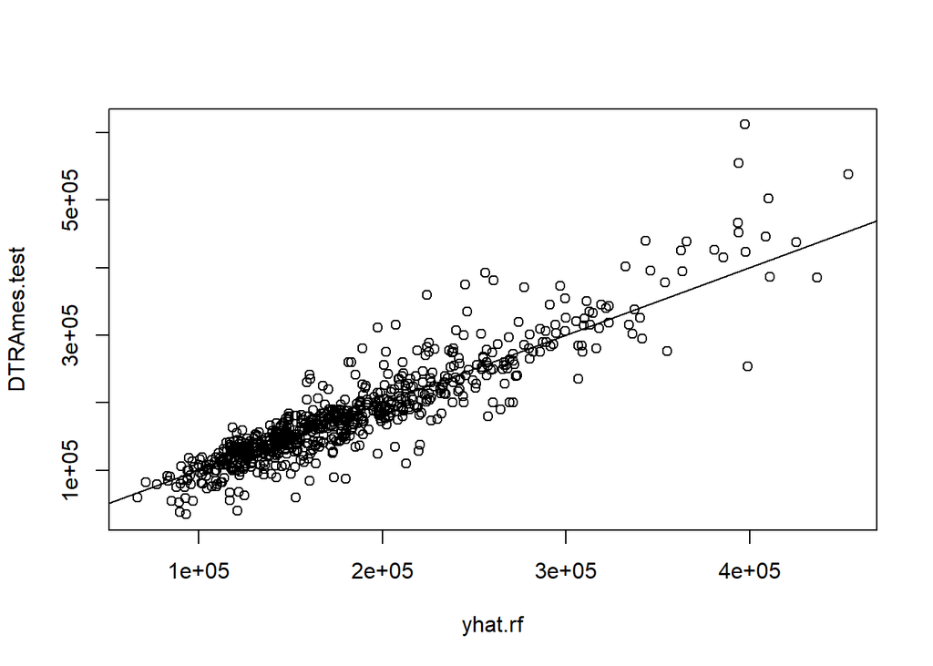

```r
yhat.rf <- predict(rf.DTRAmes, newdata = DTRAmes[-train, ])
plot(yhat.rf, DTRAmes.test)
abline(0, 1)
```

```r
mean((yhat.rf - DTRAmes.test)^2)
```

```
## [1] 984455777
```

```r
RF.RMSE <- sqrt(mean((yhat.bag - DTRAmes.test)^2))
RF.RMSE
```

```
## [1] 32047
```

We can use results from the bagging and random forest analysis for feature selection, as well. By analyzing the relative importance of features in both models, we can rank them. Notice the order of importance is identical for both through the first six features, then the order changes a great deal.

```r
importance(rf.DTRAmes)
```

```
##                      %IncMSE IncNodePurity
## GrLivArea             54.864     1.205e+12
## TotalBsmtSF           26.378     8.454e+11
## YearBuilt             47.656     8.780e+11
## Condition2_PosN        0.000     0.000e+00
## OverallQual_10         4.681     5.603e+10
## SaleType_New           4.085     2.611e+10
## Neighborhood_StoneBr   2.051     2.112e+10
## LotArea               16.409     2.299e+11
## Neighborhood_NridgHt   5.503     2.617e+10
## GarageArea            23.432     5.780e+11
## HouseStyle_1Story     10.883     3.811e+10
## Neighborhood_Crawfor  13.292     1.521e+10
## KitchenQual_Ex        16.073     1.655e+11
## Neighborhood_NoRidge   4.476     1.614e+10
## Fireplaces_2           6.541     2.389e+10
```

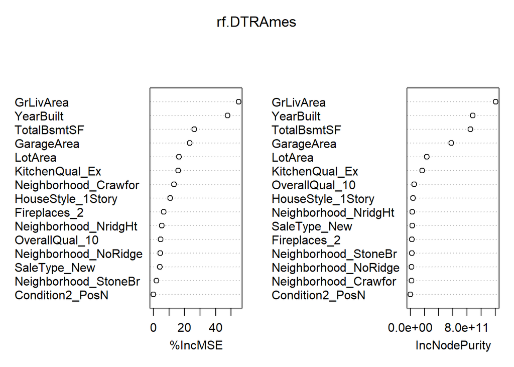

```r
varImpPlot(rf.DTRAmes)
```

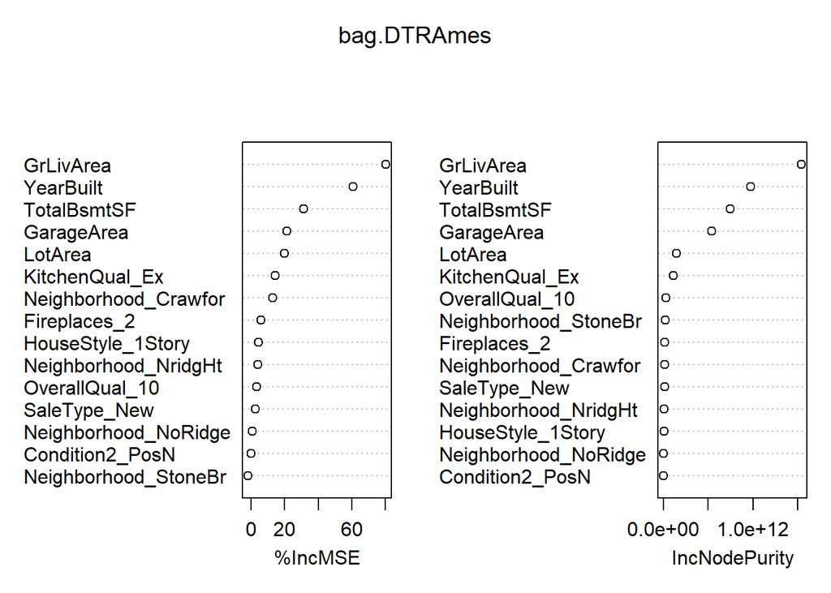

```r
varImpPlot(bag.DTRAmes)
```

# 11 Creating a Random Forest Analysis (with Boosting)

Boosting is another twist on decision trees and random forests. An ensemble method, like random forests, but it is more useful in reducing variance *and* bias. Since we are working with a regression problem, we will run the boost as a Gaussian distribution. We will set the model to run a forest of 5000 trees. The first return is a list of features ordered by importance.

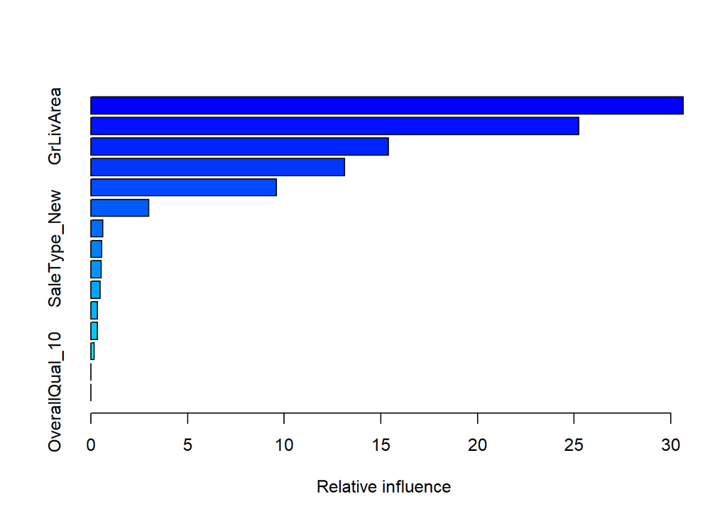

[output not shown]

```r
set.seed(805)
boost.DTRAmes <- gbm(SalePrice ~ ., DTRAmes[train, ], distribution = 'gaussian',
                     n.trees = 5000, interaction.depth = 4, shrinkage = 0.2, verbose = FALSE)
summary(boost.DTRAmes)
```

We can plot these features. Some of them are not terribly interesting because they exhibit binary behavior, but overall the visualization helps us understand why boosting chooses to order features this way.

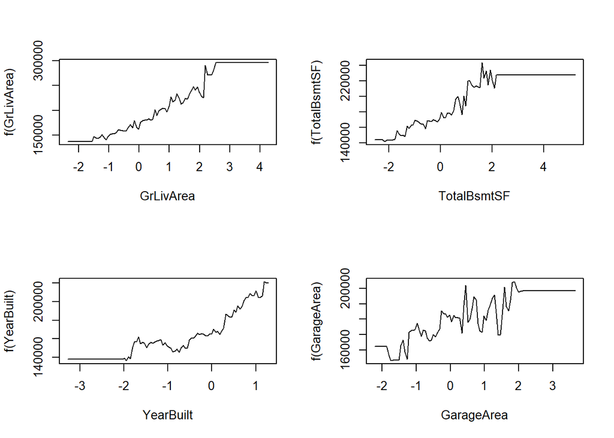

```r
par(mfrow = c(2, 2))
plot(boost.DTRAmes, i = 'GrLivArea')
plot(boost.DTRAmes, i = 'TotalBsmtSF')
plot(boost.DTRAmes, i = 'YearBuilt')
plot(boost.DTRAmes, i = 'GarageArea')
```

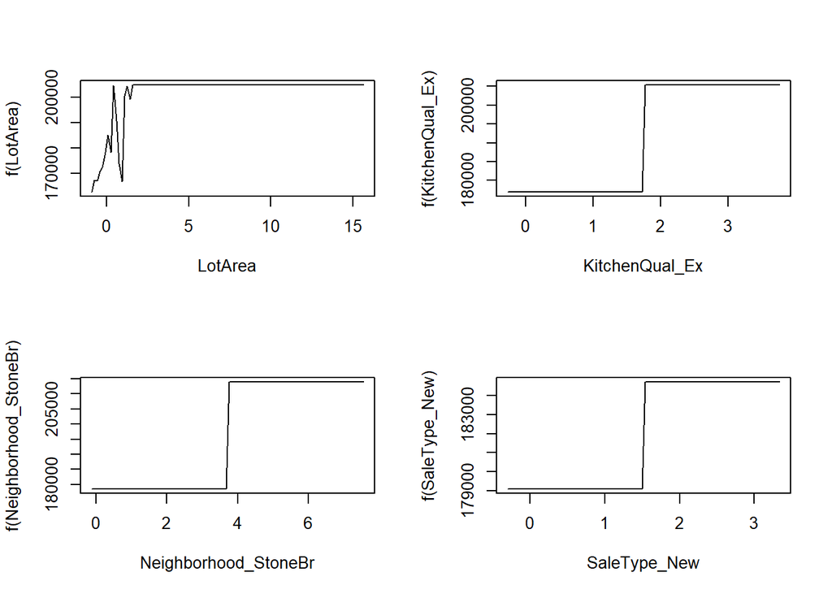

```r
plot(boost.DTRAmes, i = 'LotArea')
plot(boost.DTRAmes, i = 'KitchenQual_Ex')
plot(boost.DTRAmes, i = 'Neighborhood_StoneBr')
plot(boost.DTRAmes, i = 'SaleType_New')
```

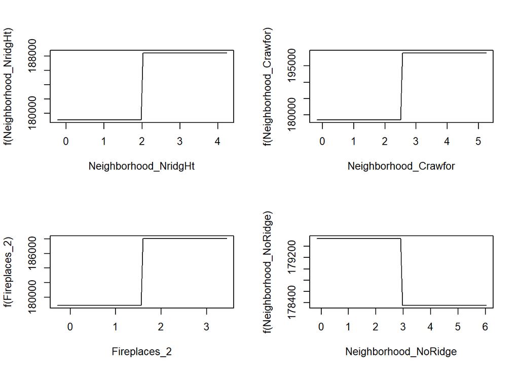

```r
plot(boost.DTRAmes, i = 'Neighborhood_NridgHt')
plot(boost.DTRAmes, i = 'Neighborhood_Crawfor')
plot(boost.DTRAmes, i = 'Fireplaces_2')
plot(boost.DTRAmes, i = 'Neighborhood_NoRidge')
```

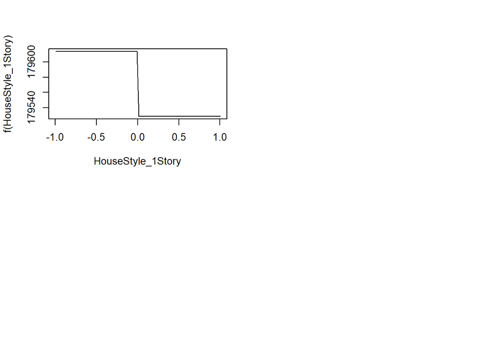

```r
plot(boost.DTRAmes, i = 'HouseStyle_1Story')
```

Moving on with the model, we can determine the *RMSE* for the boost. It is 34,963.

```r
yhat.boost <- predict(boost.DTRAmes, newdata = DTRAmes[-train, ], n.trees = 5000)
mean((yhat.boost - DTRAmes.test)^2)
```

```
## [1] 1.222e+09
```

```r
boost.RMSE <- sqrt(mean((yhat.boost - DTRAmes.test)^2))
boost.RMSE
```

```
## [1] 34963
```

# 12 Creating a Support Vector Machine

The *Ames* problem is essentially a regression problem, so we would not expect the SVM method to be very helpful. Still, we can run the data through the SVM and see what kind of results it yields. There are over 1000 support vectors in the model, which suggests it is using very wide parameters and that accuracy might suffer as a result. The results are long, so they are suppressed here, but the code can be opened up if the reviewer is interested in seeing them.

```r
svm.mod <- svm(SalePrice ~., data = AmesTrDumScaleDFShort)
svm.pred <- predict(svm.mod, lm.test)
svm.mod
```

```
##
## Call:
## svm(formula = SalePrice ~ ., data = AmesTrDumScaleDFShort)
##
##
## Parameters:
##    SVM-Type:  eps-regression
##  SVM-Kernel:  radial
##        cost:  1
##       gamma:  0.0625
##     epsilon:  0.1
##
##
## Number of Support Vectors:  1011
```

```r
#svm.pred
```

```r
mean((svm.pred - DTRAmes.test)^2)
```

```
## [1] 1.072e+10
```

```r
svm.RMSE <- sqrt(mean((svm.pred - DTRAmes.test)^2))
svm.RMSE
```

```
## [1] 103516
```

# 13 Conclusions

Every algorithm has its limitations and no algorithm is suitable for all situations. Algorithm selection Is an important cosideration for the data analyst. Fortunately, a relative few algorithms appear to be most effective against a wide variety of problems.

It is a good practice to apply a number of algorithms against any particular problem to see which might perform the best. It is also a good practice to start with a well-known few that repeatedly prove themselves effective performers. One study (Olso, *et al*, referenced in the Problem Statement), recommends five machine learning algorithms as appropriate “starting points.” Three are enemble methods. They are:

1. Gradient Tree Boosting
2. Random Forest
3. Support Vector Machine
4. Extremely Randomized Trees
5. Logistic Regression

The deployment of numerous algorithms on the *Ames* data set was a useful exercise and an important process for several reasons. First, it requires a close examination of the data and helps develop a good understanding of existing potential for analytical and predictive purposes. Second, building numerous models helps identify the limits of the data and forces the analysis to focus on what can be done with the data set. It helps avoid torturing the data, in other words.